# Forecasting the Electricity Consumption of Turkey

##### Mehmet Bahadır ERDEN, Ömer Erhan ERBİŞ, Oğuzhan Pınar - IE360 Project Report - Fall 2020

```python
from IPython.display import HTML

HTML('''<script>
code_show=true;
function code_toggle() {
 if (code_show){
 $('div.input').hide();
 } else {
 $('div.input').show();
 }
 code_show = !code_show
}
$( document ).ready(code_toggle);
</script>
<form action="javascript:code_toggle()"><input type="submit" value="Click here to see and hide the raw codes of the report."></form>''')
```

# 1. INTRODUCTION

## 1.1. Problem Description

Energy is a core resource in the current civilization of humanity. Ever since the Industrial Revolution, energy became more and more important as time went by, and this trend is still the same and will be the same for the foreseeable future. The importance energy attained in today’s world is immeasurable, therefore the field receives a solid attraction from both industrial organizations, applied sciences field workers and theoretical researchers.

The attraction can be divided into two seperate yet highly connected sides of the energy sector, named production and consumption sides. Since the demand is the reason supply is created and supply impacts demand in variaous ways such as prices, they are highly connected. Since this connection also determines main dynamics in the system, both sides require a detailed overlook of the other to reach correct and meaningful results in their analyses.

In this applied research project, our aim is to predict (electricity) consumption demand of the (Turkey)society. The reason behind this aim is to create an accurate forecast of consumption demand values for some future interval that will actually determine the production facilities periodical choices and energy output amounts.

This is important for production facilities due to several reasons:

```
1- Insufficient energy production that falls short of the energy consumption demand will cause energy shortages, inefficient supply of energy for some energy-dependent processes, local power outages in severe cases. These may cause inefficiencies and direct or indirect harms to society (i.e. deaths in intense care units due to no power supply) and world (inefficient utilization of energy may cause more natural resource use to reach target goals that may lead natural resource depletion).
2- Excess energy production over normal demand is needed to be utilized, if possible. There exists some processes and facilities that this energy can be utilized in various ways, but due to these being not necessary, they ask for a reduced price from energy producers, to bear the consequences of their over-production. Likewise, if there is a shortage in terms of supplying the electricity by the distributor companies, these companies have to satisfy this demand by paying for a over-price from energy producers.
3- Energy is not a storable resource in large amounts due to the nature of energy (also, electricity). This causes the excess supply of demand to be a waste of precious resources, if not utilized in any way. In some cases, this is done via grid frequency increases or energy dumping into meaningless circuits, both causing higher heat dissipation (possible harm to global ecosystem).
```

These adversities and inefficiencies created by the insufficient or excess production are severe problems. However, due to some controllable energy production processes and via correct assessment of consumption demands, many of these are prevented nowadays. This project also plans to correctly estimate a type of energy, electricty consumption demand values due to the reasons above to create an opportunity to reach optimal energy production values in Turkey.

## 1.2. Summary of the proposed approach

To correctly forecast and to enable producers decide more accurate production amounts, we utilized the electricity consumption dataset available on EPIAS platform up to the present day. Available data is set to be searched by the computer statistical analysis methods, and via learned information the correct consumption values are expected to be estimated for future periods.

Many statistical data analysis models exist and they may provide different values with different fitted models with different accuracies. Therefore, the data is divided into train and test intervals as it is the norm in any data analysis conducted.

We decided on a selection industry and literature norm models to be trained on the train data, considering qualifications of our data's qualities. This led us to perform statistical model analysis methods (details given in 2.Literature Review).

The data at hand is hourly dataset. However, inspections demonstrated that daily data may be another good-performant and this is to be investigated in models to decide on final model. Also, hour-based (models on individual hours "00:00", "01:00", ...) machine-learning models are another viable option that are to be investigated in the project. Additionally, moving-window approach is another option to be investigated to not lose data for precision that may lead better forecasts.

In the model training, fluctiations and diversions from the norms are to be investigated via chosen -believed to be- related external regressors (see 2.Literature Review). On top of it, still present outlier values are to be checked via visual and data analysis methods, and reasons of these to be inspected via "news of the day" search to provide extra input or smoothen the existent data. Via this, stationarity is expected to be reached to accurately perform data analysis.

After all, fitted trained models are to be checked on the test-period to assess the model performance. Also, overfitting phenomenon is expected to be checked via this process and if existent, neccessary measures are expected to be taken.

After the decision of the best model option, with the use of all available up-to-date data to not lose precision, forecasts are expected to be found with proposed methods for time t+1 while utilizing data up-to time t-1 at time t on timeline (t's are days here).

Best model results are still object to a manual criticism for further corrections, and after all these steps, the most accurate forecasts to be found and provided as results.

## 1.3. Descriptive Analysis of the given data

We have hourly electricity consumption values of Turkey from 2017 Jan 01. For the forecasting we will have data until the 2 days before of the predicted day. In order to clarify the structure of the data, it will be using data until 2021 Jan 07 for this report. Also, we will present our analysis for exogenous variables, including temparature, after the literature review section.

```python
import pandas as pd
import numpy as np
import seaborn as sns
import datetime as dt
import matplotlib.pyplot as plt
import statsmodels.api as sm
from statsmodels.tsa.seasonal import DecomposeResult, seasonal_decompose
from statsmodels.tsa.stattools import kpss
import warnings
warnings.filterwarnings("ignore")
import pmdarima as pm


df = pd.read_csv("bulk_consumption_with_temp.csv")
df.Date = df.Date.apply(lambda x: dt.datetime.strptime(x, "%Y-%m-%d"), 1)
df["hourly_date"] = df.apply(lambda x: dt.datetime(x["Date"].year, x["Date"].month, x["Date"].day, x["Hour"] ), 1)
df = df.set_index("hourly_date")
daily_data = pd.DataFrame(df.groupby(by = "Date").Consumption.mean())

df
```

| hourly_date | Date | Hour | Consumption | T_1 | T_2 | T_3 | T_4 | T_5 | T_6 | T_7 |
| --- | --- | --- | --- | --- | --- | --- | --- | --- | --- | --- |
| 2017-01-01 00:00:00 | 2017-01-01 | 0 | 25409.3134 | -15.88 | 4.18 | 0.89 | -18.96 | -14.77 | -10.68 | 2.16 |
| 2017-01-01 01:00:00 | 2017-01-01 | 1 | 24166.1420 | -15.88 | 4.18 | 0.89 | -18.96 | -14.77 | -10.68 | 2.16 |
| 2017-01-01 02:00:00 | 2017-01-01 | 2 | 22652.0209 | -15.88 | 4.18 | 0.89 | -18.96 | -14.77 | -10.68 | 2.16 |
| 2017-01-01 03:00:00 | 2017-01-01 | 3 | 21578.0522 | -15.88 | 4.18 | 0.89 | -18.96 | -14.77 | -10.68 | 2.16 |
| 2017-01-01 04:00:00 | 2017-01-01 | 4 | 21018.1962 | -15.88 | 4.18 | 0.89 | -18.96 | -14.77 | -10.68 | 2.16 |
| ... | ... | ... | ... | ... | ... | ... | ... | ... | ... | ... |
| 2021-01-07 19:00:00 | 2021-01-07 | 19 | 40248.7500 | 3.52 | 13.55 | 12.90 | 6.73 | 8.81 | 5.71 | 13.89 |
| 2021-01-07 20:00:00 | 2021-01-07 | 20 | 38969.8100 | 3.30 | 13.24 | 12.43 | 6.33 | 8.36 | 5.43 | 13.79 |
| 2021-01-07 21:00:00 | 2021-01-07 | 21 | 38016.7600 | 3.32 | 12.83 | 11.92 | 5.96 | 8.19 | 5.46 | 13.77 |
| 2021-01-07 22:00:00 | 2021-01-07 | 22 | 37439.2000 | 3.48 | 12.62 | 11.84 | 5.70 | 8.14 | 5.58 | 13.68 |
| 2021-01-07 23:00:00 | 2021-01-07 | 23 | 36241.5900 | 3.61 | 12.34 | 11.78 | 5.67 | 8.27 | 5.60 | 13.60 |

35232 rows × 10 columns

We have 35232 data points in our analysis. In order to inspect the seasonality and trend we will plot the all Hourly data. But due to the abundance of the data points the plot of hourly data may not be intuitive. Therefore, we will also have the plot of Daily mean consumption. Finally, we will have zoomed hourly consumption plot of a couple of days in order to inspect hourly structure of the data.

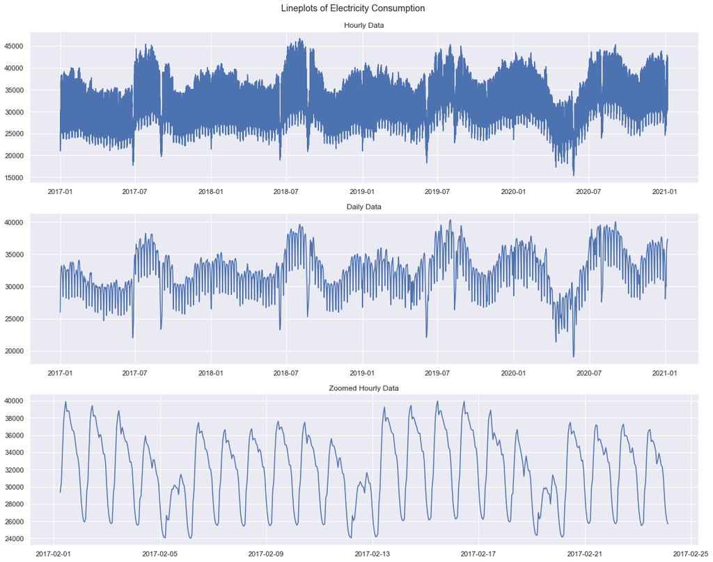

```python
sns.set(rc={'figure.figsize':(19,15)})

fig, axs = plt.subplots(3,1)
fig.suptitle('Lineplots of Electricity Consumption', y = 0.92)

sns.lineplot(data = df.Consumption, ax=axs[0]).set_title('Hourly Data')
sns.lineplot(data = daily_data.Consumption, ax=axs[1]).set_title('Daily Data')
sns.lineplot(data = df.Consumption[750:1300], ax=axs[2]).set_title('Zoomed Hourly Data')
```

By visual inspection of the above graphs;

```
1. The mean of the data is changing over time, therefore, the series is not stationary. We have to provide stationarity to apply our models by extracting trend and seasonality components from the data.

2. From the first two plots, the variance of the data is seem to be constant over time. Therefore, box-cox transformations will not be so important in our models. In addition, there is a decrease in the consumption of electricity at first and second quarter of the 2020, which reasoned from the pandemic. Therefore, undergoing pandemic makes Box-Cox transformation insignificant.

3. There are too low values every year. We know from the lectures that those are new year, religious and national holidays. In order to improve our models a closer look is required for those days. Therefore, we will decompose the trend ans seasonality and analyze big residuals one by.

4. We have higher consumption levels for summer months. Therefore, the month of the forecast is going to be important for our models.

5. From the third plot we observe daily seasonality since there is low consumption at nights and higher consumption during the days.

6. Also it is observed that we have close consumption levels for the same days of the week and low consumption values for weekends therefore, there we have weekly seosanality.

7. Finally we observe some unusual structure during the COVID period. Therefore, we shold add covid period to our features wisely. As we will show in later parts we used Google trends data for covid severity.

8.In the COVID period, the government took some preventions to decrease the effect of the pandemic. One of the prevention is a lockdown. These days' consumption values are also affected were determined by visual inspection. Moreover, it can be said that the effect of lockdown has changed over the period of the pandemic duration.
```

Now, it will be checked the autocorrelations and partial correlations.

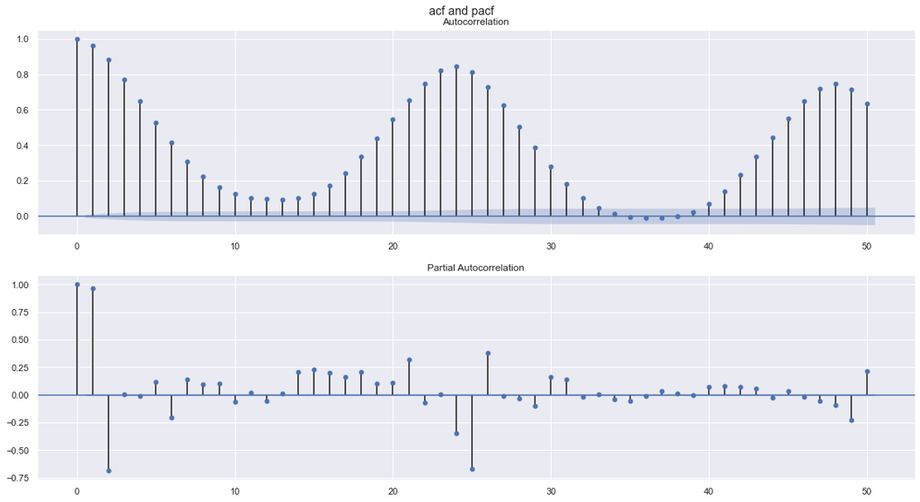

```python
sns.set(rc={'figure.figsize':(19,10)})

fig, axs = plt.subplots(2,1)
fig.suptitle('acf and pacf', y = 0.92)
sm.graphics.tsa.plot_acf(df.Consumption, lags=50, ax=axs[0])
sm.graphics.tsa.plot_pacf(df.Consumption, lags=50, ax=axs[1])
plt.show()
```

We have significant partial autocorrelaions at 1st, 2nd, 24th lags. Therefore, those lags will be important in our models.

## 1.4. Challenges

Time-series quality of our data poses challenges to the project since external regressors that are to be used will be required to be proxies or forecast values. This inevitably results in imprecision and errors for forecasts.

Due to above reasons, availability, accessibility and relation reasons, feature selection for our models poses another problem to be carefully inspected upon. Finding such features through literature review and facts of energy & electricity consumption requires thorough investigation. Furthermore, features that are highly correlated with consumption are required to be incorporated into the model for precision but multicollinearity should be checked and additinal regressors' computation costs should be considered.

Also, feature data available may have lower frequency than our models' use that creates a time mismatch. This also should be correctly assessed to not lose performance of the forecasts.

COVID-19 pandemic also creates an issue due to being unexpected and its effects being ambigious that varies with public & world sentiment. This is highly variant and reflects on the consumption values hugely due to consumption values' dependency on industrial production and household consumption that are results of individuals' decisions. Effects of pandemic should be incorporated carefully into the model to minimize errors (perfection is believed to be not possible).

Dealing with outliers is yet another problem that affects model performance. Reasonably detectable and correctible outliers creates a somewhat smaller problem. However, unexpected outliers that may reflect public's tendencies and actions (e.g. collective holiday extension and collective use of annual leave) that are hard to deal with poses a challenge to be worked upon.

# 2. Literature Review

The nature of electricity consumption being a time-series data creates many dimensions to consider in forecasting. Despite utilizing both econometric and machine-learning tecniques, our models learn from the past data points and predict future points and will be returning forecasts with errors due to time-inconsistency and other factors. This may also include external regressors’ prediction errors, yet again a result of the nature of time-series data forecasting.

Therefore literature revolves around various analysis models and tries to cope up with the qualities that make the predictions inaccurate. The electricity consumption data demonstrates non-linear, stochastic and time-variant patterns that makes its analysis hard and predictions to be inaccurate (Li and Zhang, 1). Therefore, approaches to analyse and forecast the electricty consumption are seperated into three main dimensions: Statistical Analysis Models, Computational Intelligence Models and Grey Prediction Models (Li and Zhang, 2).

Statistical Analysis Models include classic and logistic regression models, time-series models (e.g. ARIMA) and Markov chain models. These models are very reliable models since some are especially designed to cope up with time-series data but have little shortcomings. With the data at hand being in a sufficient amount with required statistical qualities and with choosing accurate external regressors, these models have high accuracy in the literature (Li and Zhang, 2). They are also very popular models in the use due having various applications that are suitable for many time-series data.

Computational Intelligence Models are composed of highly-advanced Support Vector Machine Regression (SVM) systems and neural-network (NN) systems with variaous extension and derivatives. These are very popular in advanced machine-learning analyses with advanced applications.

Grey Prediction Models are in the middle of black-box and white-box models that aims for a better analysis and prediction. It uses data to complete the partial knowledge of theoretical structure to reach a better model via combination of both theory and realizations (using data). They are also very popular in some cases as the assumption of the model is logical but they are hard to implement. The model assumptions also conform many qualities of electricity consumption data and forecasting, therefore being popular in this field as well.

First of all, energy consumption demand investigations and forecasts existed since mid 1900s with the initiative of State Planning Organization, and Ministry of Energy and Natural Resources have continued those efforts developing Model of Analysis of the Energy Demand (MAED) at the end (Ediger, Akar). This model is also said to be currently used effectively for forecasting electricity consumption demand. Of course seperate models and approaches followed these with other interested parties’ active involvement in the studies.

Ediger, Akar (2006) worked on energy consumption demand and found ARIMA model forecasts to be the most reliable model amongs other individual model forecasts they compared. They deemed ARIMA model to be efficiently usable approach in energy consumption forecasts. Also, many additional global energy electricty centered research focused and deemed multiple linear or logistic regressions and time-series analyses to be viable options amongst alternatives.

Kaytez et al (2015) worked on Turkey’s electricity consumption demand forecasts, utilizing Least-Squares Support Vector Machines, Artificial Neural Networks(ANN) and found SVM to be the best model with error of 0.01004 for their test period without significant overfitting. They compared TEIAS 2008 electricity consumption demand projection error of 2008 (error = 0.1181) to theirs and suggested that LS-SVM model to be a better forecasting model for electricity consumption demand. Ogcu et al (2012) also did a research on electricity consumption demand of Turkey with Support Vector Machines Regression (SVM) and Artificial Neural Networks (ANN) amongst other Neural Network alternatives and reached the conclusion of SVM being a better forecasting model than NN counterpart.

Sahin (2018) also made analysis and created a Grey Prediction Method for forecasting future electricity consumption demand of Turkey. In his results, Grey Prediction Method returned with 0.0308 Mean Absolute Performance Error (MAPE) score for 1996-2016 period. Li and Zhang (2018) also performed their analysis on Grey Prediction Method models. There are also many Grey Prediction Method models for forecasting in energy and electricity consumption and production values and it seems that the literature is utilizing this method more effectively recently.

In addition to these dimension-specific research, Kaynar et al (2017) combined SVM with Chaotic Particle Swarm Algorithm in their research and reached 0.036 error in their hybrid model results. They claimed their hybrid model to be better than ANN models. Furthermore, Sisman (2016) investigated and set up a forecasting models of electricity consumption demand of Turkey with ARIMA and Grey Prediction Model processes in his study, and reached very good Mean Absolute Performance Error (MAPE) scores of 0.049 and 0.056 in order.

To take a note here, many models used external regressors in their research to reach more robust models. Amongst them, Kaynar et al (2017), Kankal et al (2011) and Ediger, Akar (2006) utilized economic regressors such as imports, exports and GDP in their models, excluding some researches that were in times of economic crises. Also, demographic parameters such as population characteristic traits, total population, unemployment etc. are widely used in the research field, and such examples can be found in the works of in Zaid Mohamed, Pat Bodger (2003), Wang et al (2018) and Kaytez et al (2015).

These all shows that different settings and regressor choices affect model performances hugely and Statistical Analysis models are good models for forecasting electricity consumption demands with the data supporting required qualities. Since our data at hand provided by EPIAS, EVDS and many relative APIs are large enough with required statistical qualities, choosing accurate regressors will make us able to utilize these models over others while being relatively less complicated and easy to implement.

# 3. Approach

After Literature Review, possible information affeting the electricity consumption in Turkey, and models enabling to predict future consumption are determined. There are 2 main aim to use mentioned type of information. The first one is that usage of the information to detect outlier points in the daily electricity consumption. The other is to explain variation in the consumption by using regressors by obtained information.

To make it more clear, outlier days' effects tried to be removed by using interpolation technique. In order to determine outlier days, possible days are checked. Details of these days explained in the section 3.1. After finding those days, value of outliers replaced by mean of 2 week before, 1 week before, and 1 week after consumption with different weights. In replacement process, wheter determined 3 days are outliers/special days or not checked and after that the replacement is made. By doing interpolation, other possible outliers hard to detect checked by tsoutliers() and tsoutliers() gave these other outliers more easily because of the preprocessing in the outliers remove. In this process, days which are not formal holidays but people combined these days with formal holidays are found. Moreover, other special situation effects such as first lockdown in weekend period in Turkey detected by tsoutliers(). The main objective of removing these days is having a good input for both time-series models and regressors. In addition, there are no special day in the prediction period is also one of the reason for removing effect of these days.

Other Feature also determined by considering literature reviews, pandemic, and possible critical factors for electricity consumption. Details of all these features are also given in the section 3.1.

In the model perpective, different models are tried. Which models are tried can be listed as:

- Linear Regression
- Decision Tree
- Random Forest
- Linear Model Tree
- Linear Regression with Lasso Penalty
- AR Model
- MA Model
- ARIMA Model

Some of the models were not proper for the consumption estimation. These models can be Decision Tree and Random Forest because extrapolation doesn't exist for these 2 models. Much as Linear Model Tree is the best tree among the Tree models, dataset didn't be proper for using Linear Model Tree. In addition, linear regression was too simple to explain variation in the consumption with limited feature dataset. After adding extra features, Linear Regression with Lasso Penalty were considered to eliminate insignificant features. In time series model perspective, all the mentioned 3 time-series models were tried. auto.arima() function gave the best model among the mentioned models. Lastly, one naive model was created in hourly consumption data with lag 168. The main aim of the naive model is to compare obtained result from the models by this naive model. All the codes for models will be added to the code section at the end, but only determined models' details will be mentioned in the Model section of the report.

In addition to model selection, there are 2 option for testing models. One of them is predicting all test dataset without a slicing windows technique. The other one is predicting with sliciding window. By considering the how to predict in the submission system, all the comparisons made by predictions with slicing window technique.

To sum up, there are 3 main models. These are naive model, linear regression with lasso penalty, and arima model with auto.arima() function. The details of these 3 models will be explained in the Model part of the project report.

## 3.1. Outlier analysis and Feature Engineering

In order to gather the unusual days which has a crucial role to provide stationarity and for feature engineering process, we decomposed our daily data and and checked the unusual electricity consumption days.

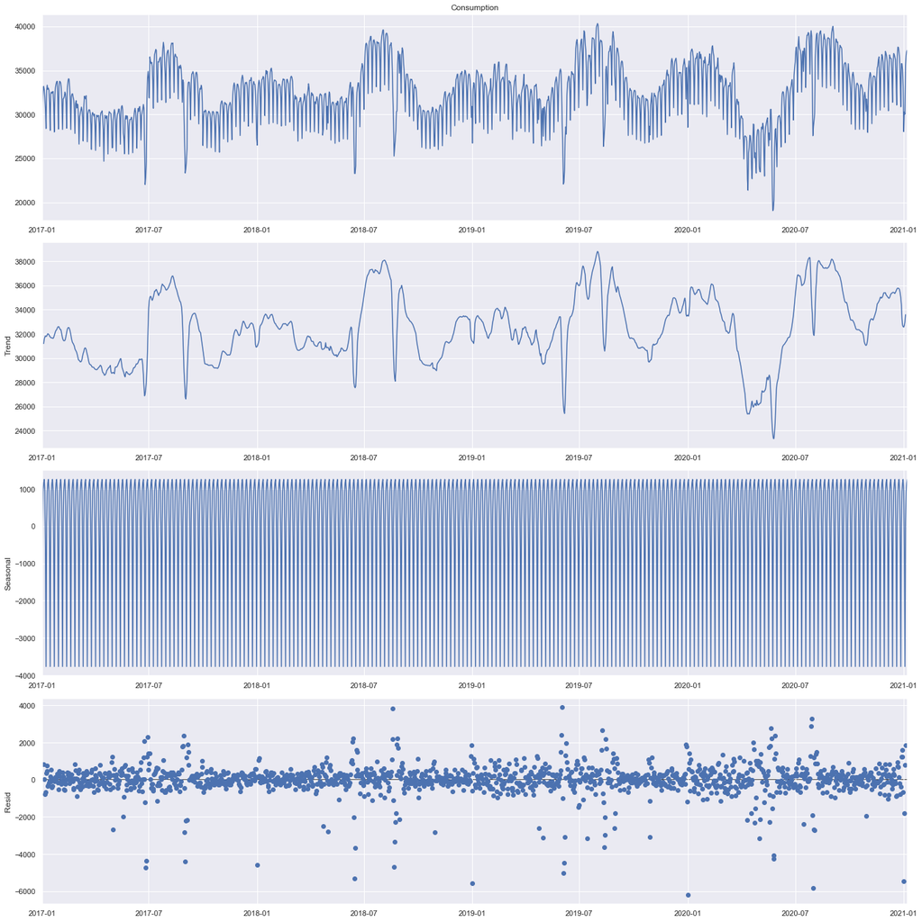

```python
sns.set(rc={'figure.figsize':(19,19)})

decompesed_data = seasonal_decompose(daily_data.Consumption, model = "additive" )
decompesed_data.plot()
plt.show()
```

Using the decomposition results above, we have determined the unusal days by considering the mean and standart deviation of resid part. We have labeled a day as unusual if it is 1.85*st_dev or more far from the mean. The labeled observations were generally official holidays like New year, Ramadan aid, Sacrifice aid, 23 April etc. Apart from holidays, we analysed the anomaly days one by. The findings and solutions from analysis of those days are;

#### Official and Combined Holidays

Official holidays have negative impact on electricity consumption. However, the impact of different holidays were not similar to each others; therefore, to handle this issue, we added every holiday values as **different dummy variable** each holiday. Details of the dummy variable can be listed as follows(sequence represents the factor number in the feature dataset):

1. New year
2. National Holidays
3. Eid al-adha
4. Eid al-Adha eve
5. Ramadan
6. Ramadan eve
7. Unioned formal holidays with government decision
8. Days combined with other formal holidays and special lockdowns
9. First lockdowns in the April and May

"Days combined with other formal holidays and special lockdowns" can be listed as(which formal holidays/Special days):

- 2017 Ramadan
- 2017 Victory Day
- 2018 Eid al-Adha
- 2019 Ramadan
- 2019 Eid al-Adha
- 2019 Victory Day
- First 3-week break given to schools in Turkey
- First lockdowns(Saturdays) in the April and May.

#### Lockdowns

Lockdowns have reducing impact on electricity consumption. As a solution of this is_lockdown feature added. For daily models it is added as factor 1 for partial lockdown (only evenings) 2 for full_lockdowns. For hourly models, these 2 information added to models by 2 different features.

#### COVID - 19 period

During COVID - 19 period some unusual patterns are observed evenif there was no lockdown. However, the impacts of the covid period was not stable during the all covid period. Therefore, adding a binary variable indicating covid period would not be sufficent for this problem. After observing the data, the impacts of the COVID was seem to be related with the severity of covid. Therefore, we used gogle trend popularity data of Covid topic as an indicator showing the severity of COVID-19.

#### Weekdays betwen two holidays

The days between two holidays are found to be important. Those are added as another factor to holiday data.

#### Political Events

Some political events are found to be important like Afrin events and a conflict between Turkey and Holland. However, the consumption values of such days were high in contrast to the intuition. Therefore, we did not add them as feature to our models.

#### Found Outliers with tsoutliers() function

For some outliers, it is hard to explain why there is an extraordinary situation by looking the formal holiday time schedule or weekdays between two holidays. Namely, these days are combined with other holidays by people by took holiday leave for those days. In addition, effects of the first lockdowns in Turkey has more effects than other lockdowns. These time period can be stated as April and May in 2020. Much as lockdowns were implemented for both saturday and sunday, consumption in the saturdays were more affected. So, only saturdays were labeled in this time period.

### Other Features

We have determined the reasons behind almost all low outliers with findings mentioned above. However, we still lack to explain the reasons behind the high outliers. As mentioned in the literature review section, the macro variables are widely used for electricity consumption models. Hopefully, the higher outliers are explained from such macro variables and other features that we use in our analysis. Which are the following;

#### Production Capacity Rate

We observed higher electricity consumption levels during the day compared to nights and weekdays compared to weekends. This indicates that the electricty is used at industry during their production process. Therefore, the used portion of the all production capacity shall be important for electricity consumption. This data is publicly available at TCMB database and announced every month. We used this data by simply writing the same value for each day of a month. And for the month that we make our predictions, we used the forecasted values of the data.

#### Price of Electricity

There is a commonly known fact that demand of a good is negatively correlated with its price. Therefore, we have included the price of electricity to our analysis. The daily price data is gathered from EPDK. (https://www.epdk.gov.tr/Detay/Icerik/3-0-1/tarifeler)

#### Usd/Try Exchange Rate

We know from the previous homeworks of this course that, Usd/Try Exchange Rate has a significant role on the perception of economical situation of Turkey. Therefore, we included this rate to our features. The data is gathered from Investing API.

#### Is there sun

Since a significant part of the electricity is consumed for lighting, the consumption is expected to change with whether the sun rised or not. In addition, sunlight can be a thing as the beginning of the days for a lot of people and especially for conservative people in Turkey. For hourly models, this feature is used as a binary feature, for daily models, it is used by calculating the light time of the day. The data is gathered by using API for praying times. (https://aladhan.com/prayer-times-api)

#### Dummy Features Indicating the Day

We observed significant relationships with the same days of the weeks. Therefore, we included weekdays as dummy variables. Also we observed different consumption habits in different months therefore, we also included the months as dummy variables.

Note that, we used some different combinations of features in different models. You can check below dataframe which is the transpose of the all potential features that we use in our models.

```python
feature_df = pd.read_csv("all_features_with_dummies.csv").set_index("date")
all_data = daily_data.merge(feature_df, how="left", left_index=True, right_index=True)
all_data.T
```

| Date | 2017-01-01 | 2017-01-02 | 2017-01-03 | 2017-01-04 | 2017-01-05 | 2017-01-06 | 2017-01-07 | 2017-01-08 | 2017-01-09 | 2017-01-10 | ... | 2020-12-29 | 2020-12-30 | 2020-12-31 | 2021-01-01 | 2021-01-02 | 2021-01-03 | 2021-01-04 | 2021-01-05 | 2021-01-06 | 2021-01-07 |
| --- | --- | --- | --- | --- | --- | --- | --- | --- | --- | --- | --- | --- | --- | --- | --- | --- | --- | --- | --- | --- | --- |
| Consumption | 25975.013708 | 31293.858354 | 32666.973683 | 33190.914567 | 32824.979892 | 31913.977383 | 30526.685483 | 28388.016096 | 32672.649379 | 33323.621317 | ... | 35763.203750 | 35090.798750 | 33190.744583 | 28036.248333 | 30276.934583 | 30023.358333 | 35548.277917 | 36723.257917 | 37182.322917 | 37299.572917 |
| covid_severity | 0.000000 | 0.000000 | 0.000000 | 0.000000 | 0.000000 | 0.000000 | 0.000000 | 0.000000 | 0.000000 | 0.000000 | ... | 29.081323 | 26.707338 | 22.552863 | 29.674820 | 27.300834 | 29.674820 | 25.520345 | 26.707338 | 24.926848 | 23.146359 |
| sunlight_time_minutes | 558.000000 | 558.000000 | 559.000000 | 560.000000 | 561.000000 | 562.000000 | 563.000000 | 564.000000 | 565.000000 | 567.000000 | ... | 555.000000 | 556.000000 | 557.000000 | 558.000000 | 558.000000 | 559.000000 | 560.000000 | 561.000000 | 562.000000 | 563.000000 |
| production_capacity_rate | 77.000000 | 77.000000 | 77.000000 | 77.000000 | 77.000000 | 77.000000 | 77.000000 | 77.000000 | 77.000000 | 77.000000 | ... | 75.600000 | 75.600000 | 75.600000 | 75.400000 | 75.400000 | 75.400000 | 75.400000 | 75.400000 | 75.400000 | 75.400000 |
| price_of_electricity | 20.521900 | 20.521900 | 20.521900 | 20.521900 | 20.521900 | 20.521900 | 20.521900 | 20.521900 | 20.521900 | 20.521900 | ... | 51.740700 | 51.740700 | 51.740700 | 55.154400 | 55.154400 | 55.154400 | 55.154400 | 55.154400 | 55.154400 | 55.154400 |
| usdtry | 3.527700 | 3.544500 | 3.594300 | 3.571300 | 3.592700 | 3.644500 | 3.644500 | 3.644500 | 3.712900 | 3.788500 | ... | 7.381500 | 7.377400 | 7.439200 | 7.439200 | 7.439200 | 7.439200 | 7.419800 | 7.385600 | 7.304700 | 7.314900 |
| monday | 0.000000 | 1.000000 | 0.000000 | 0.000000 | 0.000000 | 0.000000 | 0.000000 | 0.000000 | 1.000000 | 0.000000 | ... | 0.000000 | 0.000000 | 0.000000 | 0.000000 | 0.000000 | 0.000000 | 1.000000 | 0.000000 | 0.000000 | 0.000000 |
| tuesday | 0.000000 | 0.000000 | 1.000000 | 0.000000 | 0.000000 | 0.000000 | 0.000000 | 0.000000 | 0.000000 | 1.000000 | ... | 1.000000 | 0.000000 | 0.000000 | 0.000000 | 0.000000 | 0.000000 | 0.000000 | 1.000000 | 0.000000 | 0.000000 |
| wednesday | 0.000000 | 0.000000 | 0.000000 | 1.000000 | 0.000000 | 0.000000 | 0.000000 | 0.000000 | 0.000000 | 0.000000 | ... | 0.000000 | 1.000000 | 0.000000 | 0.000000 | 0.000000 | 0.000000 | 0.000000 | 0.000000 | 1.000000 | 0.000000 |
| thursday | 0.000000 | 0.000000 | 0.000000 | 0.000000 | 1.000000 | 0.000000 | 0.000000 | 0.000000 | 0.000000 | 0.000000 | ... | 0.000000 | 0.000000 | 1.000000 | 0.000000 | 0.000000 | 0.000000 | 0.000000 | 0.000000 | 0.000000 | 1.000000 |
| friday | 0.000000 | 0.000000 | 0.000000 | 0.000000 | 0.000000 | 1.000000 | 0.000000 | 0.000000 | 0.000000 | 0.000000 | ... | 0.000000 | 0.000000 | 0.000000 | 1.000000 | 0.000000 | 0.000000 | 0.000000 | 0.000000 | 0.000000 | 0.000000 |
| saturday | 0.000000 | 0.000000 | 0.000000 | 0.000000 | 0.000000 | 0.000000 | 1.000000 | 0.000000 | 0.000000 | 0.000000 | ... | 0.000000 | 0.000000 | 0.000000 | 0.000000 | 1.000000 | 0.000000 | 0.000000 | 0.000000 | 0.000000 | 0.000000 |
| sunday | 1.000000 | 0.000000 | 0.000000 | 0.000000 | 0.000000 | 0.000000 | 0.000000 | 1.000000 | 0.000000 | 0.000000 | ... | 0.000000 | 0.000000 | 0.000000 | 0.000000 | 0.000000 | 1.000000 | 0.000000 | 0.000000 | 0.000000 | 0.000000 |
| Jan | 1.000000 | 1.000000 | 1.000000 | 1.000000 | 1.000000 | 1.000000 | 1.000000 | 1.000000 | 1.000000 | 1.000000 | ... | 0.000000 | 0.000000 | 0.000000 | 1.000000 | 1.000000 | 1.000000 | 1.000000 | 1.000000 | 1.000000 | 1.000000 |
| Feb | 0.000000 | 0.000000 | 0.000000 | 0.000000 | 0.000000 | 0.000000 | 0.000000 | 0.000000 | 0.000000 | 0.000000 | ... | 0.000000 | 0.000000 | 0.000000 | 0.000000 | 0.000000 | 0.000000 | 0.000000 | 0.000000 | 0.000000 | 0.000000 |
| Mar | 0.000000 | 0.000000 | 0.000000 | 0.000000 | 0.000000 | 0.000000 | 0.000000 | 0.000000 | 0.000000 | 0.000000 | ... | 0.000000 | 0.000000 | 0.000000 | 0.000000 | 0.000000 | 0.000000 | 0.000000 | 0.000000 | 0.000000 | 0.000000 |
| Apr | 0.000000 | 0.000000 | 0.000000 | 0.000000 | 0.000000 | 0.000000 | 0.000000 | 0.000000 | 0.000000 | 0.000000 | ... | 0.000000 | 0.000000 | 0.000000 | 0.000000 | 0.000000 | 0.000000 | 0.000000 | 0.000000 | 0.000000 | 0.000000 |
| May | 0.000000 | 0.000000 | 0.000000 | 0.000000 | 0.000000 | 0.000000 | 0.000000 | 0.000000 | 0.000000 | 0.000000 | ... | 0.000000 | 0.000000 | 0.000000 | 0.000000 | 0.000000 | 0.000000 | 0.000000 | 0.000000 | 0.000000 | 0.000000 |
| June | 0.000000 | 0.000000 | 0.000000 | 0.000000 | 0.000000 | 0.000000 | 0.000000 | 0.000000 | 0.000000 | 0.000000 | ... | 0.000000 | 0.000000 | 0.000000 | 0.000000 | 0.000000 | 0.000000 | 0.000000 | 0.000000 | 0.000000 | 0.000000 |
| Jul | 0.000000 | 0.000000 | 0.000000 | 0.000000 | 0.000000 | 0.000000 | 0.000000 | 0.000000 | 0.000000 | 0.000000 | ... | 0.000000 | 0.000000 | 0.000000 | 0.000000 | 0.000000 | 0.000000 | 0.000000 | 0.000000 | 0.000000 | 0.000000 |
| Aug | 0.000000 | 0.000000 | 0.000000 | 0.000000 | 0.000000 | 0.000000 | 0.000000 | 0.000000 | 0.000000 | 0.000000 | ... | 0.000000 | 0.000000 | 0.000000 | 0.000000 | 0.000000 | 0.000000 | 0.000000 | 0.000000 | 0.000000 | 0.000000 |
| Sep | 0.000000 | 0.000000 | 0.000000 | 0.000000 | 0.000000 | 0.000000 | 0.000000 | 0.000000 | 0.000000 | 0.000000 | ... | 0.000000 | 0.000000 | 0.000000 | 0.000000 | 0.000000 | 0.000000 | 0.000000 | 0.000000 | 0.000000 | 0.000000 |
| Oct | 0.000000 | 0.000000 | 0.000000 | 0.000000 | 0.000000 | 0.000000 | 0.000000 | 0.000000 | 0.000000 | 0.000000 | ... | 0.000000 | 0.000000 | 0.000000 | 0.000000 | 0.000000 | 0.000000 | 0.000000 | 0.000000 | 0.000000 | 0.000000 |
| Nov | 0.000000 | 0.000000 | 0.000000 | 0.000000 | 0.000000 | 0.000000 | 0.000000 | 0.000000 | 0.000000 | 0.000000 | ... | 0.000000 | 0.000000 | 0.000000 | 0.000000 | 0.000000 | 0.000000 | 0.000000 | 0.000000 | 0.000000 | 0.000000 |
| Dec | 0.000000 | 0.000000 | 0.000000 | 0.000000 | 0.000000 | 0.000000 | 0.000000 | 0.000000 | 0.000000 | 0.000000 | ... | 1.000000 | 1.000000 | 1.000000 | 0.000000 | 0.000000 | 0.000000 | 0.000000 | 0.000000 | 0.000000 | 0.000000 |
| new_year | 1.000000 | 0.000000 | 0.000000 | 0.000000 | 0.000000 | 0.000000 | 0.000000 | 0.000000 | 0.000000 | 0.000000 | ... | 0.000000 | 0.000000 | 0.000000 | 1.000000 | 0.000000 | 0.000000 | 0.000000 | 0.000000 | 0.000000 | 0.000000 |
| nat_holiday | 0.000000 | 0.000000 | 0.000000 | 0.000000 | 0.000000 | 0.000000 | 0.000000 | 0.000000 | 0.000000 | 0.000000 | ... | 0.000000 | 0.000000 | 0.000000 | 0.000000 | 0.000000 | 0.000000 | 0.000000 | 0.000000 | 0.000000 | 0.000000 |
| sacrifice_holiday | 0.000000 | 0.000000 | 0.000000 | 0.000000 | 0.000000 | 0.000000 | 0.000000 | 0.000000 | 0.000000 | 0.000000 | ... | 0.000000 | 0.000000 | 0.000000 | 0.000000 | 0.000000 | 0.000000 | 0.000000 | 0.000000 | 0.000000 | 0.000000 |
| sacrifice_eve | 0.000000 | 0.000000 | 0.000000 | 0.000000 | 0.000000 | 0.000000 | 0.000000 | 0.000000 | 0.000000 | 0.000000 | ... | 0.000000 | 0.000000 | 0.000000 | 0.000000 | 0.000000 | 0.000000 | 0.000000 | 0.000000 | 0.000000 | 0.000000 |
| ramadan_holiday | 0.000000 | 0.000000 | 0.000000 | 0.000000 | 0.000000 | 0.000000 | 0.000000 | 0.000000 | 0.000000 | 0.000000 | ... | 0.000000 | 0.000000 | 0.000000 | 0.000000 | 0.000000 | 0.000000 | 0.000000 | 0.000000 | 0.000000 | 0.000000 |
| ramadan_eve | 0.000000 | 0.000000 | 0.000000 | 0.000000 | 0.000000 | 0.000000 | 0.000000 | 0.000000 | 0.000000 | 0.000000 | ... | 0.000000 | 0.000000 | 0.000000 | 0.000000 | 0.000000 | 0.000000 | 0.000000 | 0.000000 | 0.000000 | 0.000000 |
| monday_or_friday_between_holidays | 0.000000 | 0.000000 | 0.000000 | 0.000000 | 0.000000 | 0.000000 | 0.000000 | 0.000000 | 0.000000 | 0.000000 | ... | 0.000000 | 0.000000 | 0.000000 | 0.000000 | 0.000000 | 0.000000 | 0.000000 | 0.000000 | 0.000000 | 0.000000 |
| extra_holidays | 0.000000 | 0.000000 | 0.000000 | 0.000000 | 0.000000 | 0.000000 | 0.000000 | 0.000000 | 0.000000 | 0.000000 | ... | 0.000000 | 0.000000 | 0.000000 | 0.000000 | 0.000000 | 0.000000 | 0.000000 | 0.000000 | 0.000000 | 0.000000 |
| extra_holidays_2 | 0.000000 | 0.000000 | 0.000000 | 0.000000 | 0.000000 | 0.000000 | 0.000000 | 0.000000 | 0.000000 | 0.000000 | ... | 0.000000 | 0.000000 | 0.000000 | 0.000000 | 0.000000 | 0.000000 | 0.000000 | 0.000000 | 0.000000 | 0.000000 |
| partial_lockdown | 0.000000 | 0.000000 | 0.000000 | 0.000000 | 0.000000 | 0.000000 | 0.000000 | 0.000000 | 0.000000 | 0.000000 | ... | 0.000000 | 0.000000 | 0.000000 | 0.000000 | 0.000000 | 0.000000 | 1.000000 | 1.000000 | 1.000000 | 1.000000 |
| full_lockdown | 0.000000 | 0.000000 | 0.000000 | 0.000000 | 0.000000 | 0.000000 | 0.000000 | 0.000000 | 0.000000 | 0.000000 | ... | 0.000000 | 0.000000 | 0.000000 | 1.000000 | 1.000000 | 1.000000 | 0.000000 | 0.000000 | 0.000000 | 0.000000 |

36 rows × 1468 columns

The correlation heatmap of the features is shown below.

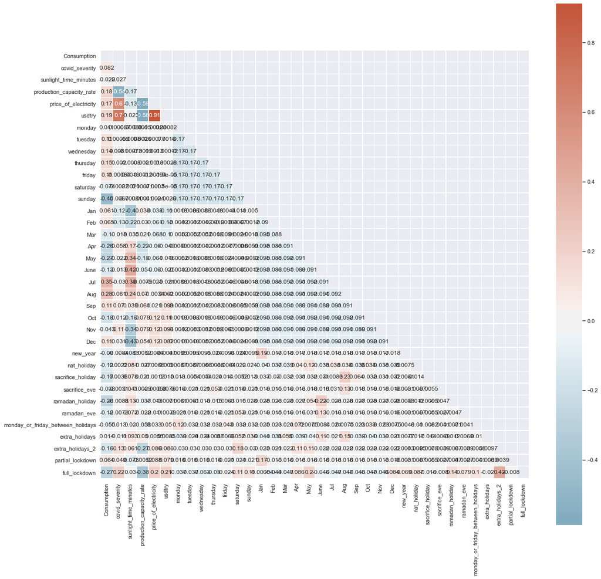

```python
# Compute the correlation matrix
corr = all_data.corr()
# Draw the heatmap with the mask and correct aspect ratio

mask = np.triu(np.ones_like(corr, dtype=bool)) # Mask for the upper triangle
f, ax = plt.subplots(figsize=(19, 19))
sns.heatmap(corr, mask=mask, cmap=sns.diverging_palette(230, 20, as_cmap=True), annot=True, center=0, square=True, linewidths=.5)
```

We observe very high correlation between electricty prices and usdtry rate. This may result with Multicollinearity problem. Therefore, we will be alerted about this issue while modelling.

#### Correlation matrix for temperature

```python
library(data.table)
```

```python
data=fread("bulk_consumption_with_temp.csv")
```

```python
cor(data[,c(4,5,6,7,8,9,10)])
```

|  | T_1 | T_2 | T_3 | T_4 | T_5 | T_6 | T_7 |
| --- | --- | --- | --- | --- | --- | --- | --- |
| T_1 | 1.0000000 | 0.9635868 | 0.9423786 | 0.9614193 | 0.9439242 | 0.9558587 | 0.9125524 |
| T_2 | 0.9635868 | 1.0000000 | 0.9305108 | 0.9422917 | 0.9323649 | 0.9455067 | 0.8957699 |
| T_3 | 0.9423786 | 0.9305108 | 1.0000000 | 0.9439996 | 0.9623408 | 0.9521646 | 0.9333808 |
| T_4 | 0.9614193 | 0.9422917 | 0.9439996 | 1.0000000 | 0.9636990 | 0.9828078 | 0.9208528 |
| T_5 | 0.9439242 | 0.9323649 | 0.9623408 | 0.9636990 | 1.0000000 | 0.9762834 | 0.9217948 |
| T_6 | 0.9558587 | 0.9455067 | 0.9521646 | 0.9828078 | 0.9762834 | 1.0000000 | 0.9212855 |
| T_7 | 0.9125524 | 0.8957699 | 0.9333808 | 0.9208528 | 0.9217948 | 0.9212855 | 1.0000000 |

There is a high correlation in all temperature values as mentioned in the description section of features. A determined method for solving this problem is to use PCA for dimension reduction in the temperature feature dataset in order to prevent multicollinearity.

#### PCA for Temperature

```python
form_pca <-prcomp(data[,c(4,5,6,7,8,9,10)], center = TRUE,scale. = TRUE)
form_pca
summary(form_pca)
```

```
Standard deviations (1, .., p=7):
[1] 2.5805636 0.3494387 0.2906455 0.2425834 0.1903095 0.1590627 0.1172339

Rotation (n x k) = (7 x 7):
          PC1         PC2        PC3        PC4        PC5         PC6
T_1 0.3791597 -0.31381154  0.3334387 -0.0803626  0.6684870 -0.41664679
T_2 0.3751841 -0.45748591  0.5252712  0.1686798 -0.5624735  0.13700961
T_3 0.3782859  0.22864923 -0.1108218  0.7473543  0.2793090  0.39417315
T_4 0.3812004 -0.14287224 -0.2687004 -0.4760813  0.1848440  0.44170871
T_5 0.3803600  0.04014929 -0.4820546  0.1814978 -0.2818853 -0.65346340
T_6 0.3822743 -0.11444116 -0.3722172 -0.2539893 -0.1749085  0.16104964
T_7 0.3691252  0.77770641  0.3968692 -0.2871324 -0.1204808 -0.06483331
            PC7
T_1  0.14018326
T_2 -0.10214075
T_3  0.02033206
T_4 -0.55330513
T_5 -0.28622103
T_6  0.76235386
T_7  0.01581387
```

```
Importance of components:
                          PC1     PC2     PC3     PC4     PC5     PC6     PC7
Standard deviation     2.5806 0.34944 0.29065 0.24258 0.19031 0.15906 0.11723
Proportion of Variance 0.9513 0.01744 0.01207 0.00841 0.00517 0.00361 0.00196
Cumulative Proportion  0.9513 0.96877 0.98084 0.98925 0.99442 0.99804 1.00000
```

PCA results gave information about how much PCA covers variance in the temperature values. Namely, 95% of variance can be represented by first principal component.

## 3.2. Performance Measure Function

In order to compare all the obtained results from models, a function is written. By this function, all the obtained result can be evaluated similar way. In this function, how many prediction is made, mean and standard deviation of the predictions, forecast bias, MAPE, Root mean square error, Mean absolute deviation, weighted mean absolute error were calculated. Indeed, WMAPE is the primary performance metric for submission system but other metrics are also calculated to understand all the perpectives of the models.

```python
perf_dt=function(type,actual,forecast){
    name=type
    n=length(actual)
    error=actual-forecast
    mean=mean(actual)
    sd=sd(actual)
    FBias=sum(error)/sum(actual)
    MPE=sum(error/actual)/n
    MAPE=sum(abs(error/actual))/n
    RMSE=sqrt(sum(error^2))/n
    MAD=sum(abs(error))/n
    WMAPE=MAD/mean
    l=data.frame(name,n,mean,sd,FBias,MAPE,RMSE,MAD,WMAPE)
    return(l)
}
```

One example for returned data frame from perf_dt() function:

```python
perf_dt("Decision Tree-Daily",test_daily$Consumption,PredictCART_daily)
```

| name | n | mean | sd | FBias | MAPE | RMSE | MAD | WMAPE |
| --- | --- | --- | --- | --- | --- | --- | --- | --- |
| Decision Tree-Daily | 38 | 839774.3 | 61167.81 | -0.007851525 | 0.02863335 | 6843.236 | 22683.19 | 0.02701105 |

## 3.3. Models

### Naive Model

As mentioned in the approach section, 3 types of models are determined after several analysis and literature review. The first model is the naive model. The main of creating naive model is to compare obtained performance measures from other models with naive model with the aiming of understanding how much improvement achieved. For this model, hourly consumption values are used to predict future consumption values. In addition, only consumption values of yesterday are available in the submission process. Therefore, lag 48 and lag 168 are used as independent feature in this model. How to determined these values can be controlled by ACF plot:

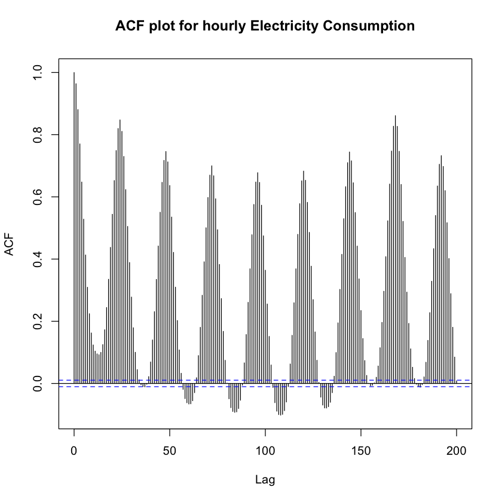

```python
acf(data$Consumption,200, main="ACF plot for hourly Electricity Consumption")
```

Lag 48 and Lag 168 are the 2 of the peak points in the ACF plot, so these values are used in the naive model. In addition, obtained information from ACF() function will be used in the other designated model to decrease auto-correlation in the residuals.

### Time-Series Model

For the time-series models, input data must be stationary in terms of mean and variation. To achieve these features in the input, interpolation is used in points of the determined outliers. Interpolation is made by replacing the the consumption of the outliers. All the outliers are labeled with different numbers and replacements are made by considering these numbers. In general, outliers values are replaced with weighted sum of 2 times 1 week before consumption, 1 times 2 week before consumption, and 2 times 1 week after consumption. In the replacement process, whether the alternative days are another special day or not checked and the replacement was done by this check. Replacement code can be found at code section.

After the replacement process, which type of prediction must be selected for future time period must be decided. There are 2 option for prediction type, daily and hourly. Both of the methods have different advantages. For hourly prediction, 24 different models must be created, and the hourly model doesn't require an additional process for splitting the daily consumption values into the hourly version. However, it is hard to determine which feature dataset is proper for xreg function because each feture has different role in each hour. In the auto.arima() models it is hard to determine which feature must be given to model in xreg regressor. This situation makes daily prediction more reasonable, but whether finding the percentage of hourly consumption in daily consumption is obtainable or not is the critical requirement for choosing the daily prediction model. First of all, a visual inspection was made to control percentage of hourly consumption in days.

This inspection was applied for January and February.All the values represent the percentage value of hours in one day. The first 2 inspections are as follows:

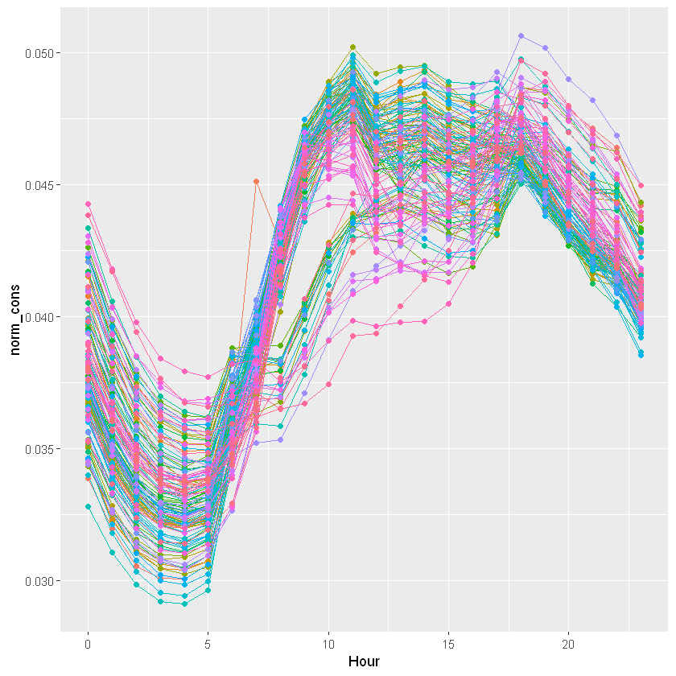

```python
ggplot(jan_obs,aes(x=Hour,y=norm_cons,color=Date))+geom_line()+ theme(legend.position = "none")+geom_point()
```

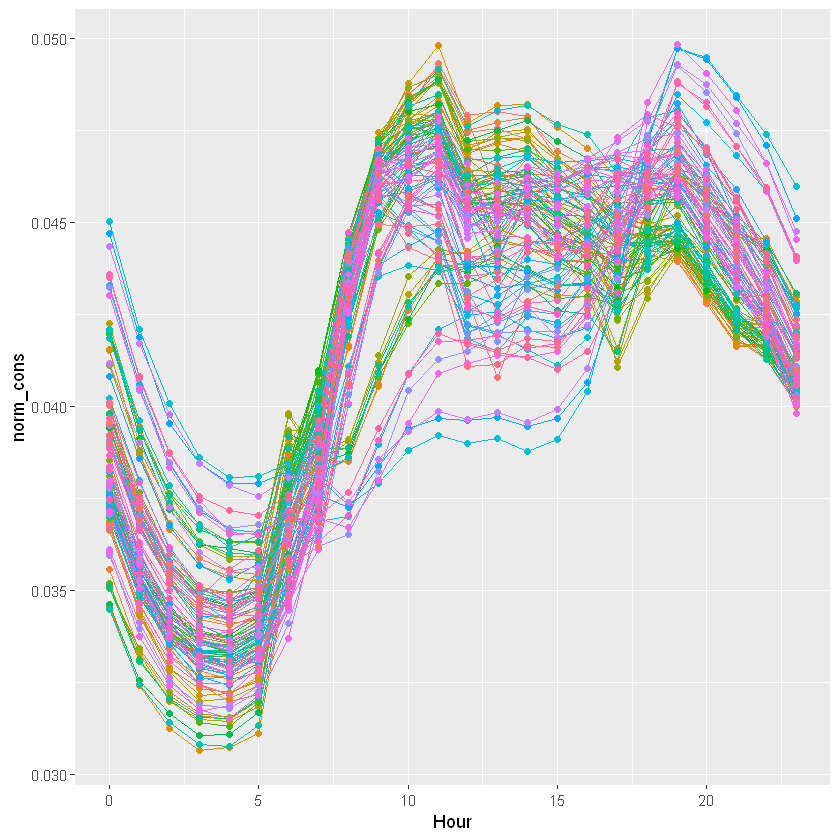

```python
ggplot(feb_obs,aes(x=Hour,y=norm_cons,color=Date))+geom_line()+ theme(legend.position = "none")+geom_point()
```

Much as there are similarities in the percentage values, some deviations can be found in the hourly consumption. In order to eliminate this situation, different inspections are tried. These inspections can be listed as:

1. Inspection for only Sundays
2. Inspection for only Saturdays
3. Inspection for only Weekdays
4. Inspection for only Weekdays without Friday
5. Inspection for only Friday

The best visual models achieved with percentage values for Sundays, Saturdays, Fridays, and weekdays without friday. Friday has a different pattern because of the Friday Pray. Much as a good percentage determination achieved with this filtering, changes in percentage over the years also controlled to understand value of percentage for each hour stationary or not. There is no change in between the years for January and February. At the end, percentage values are determined by taking mean of the percentage values for filtered datasets. On the other hand, time series were also applied for filtered dataset to predict feature percentage in the upcoming days but there are only limited dataset and it is hard to use time-series models for each filtered values. The code for this model can be found at the code section.

To sum up, 2 months' percentage values are calculated seperately. In addition, calculation were made by considering the which day of the week, and there are 4 dataset for each month. Moreover, special days such as new year days were removed form the dataset to prevent from outliers. All the visual inspections and plots can be found at code section.

In addition, Log transformation or Box-Cox transformation became unnecessary for consumption dataset because of the pandemic period. This situation can be understood by looking the plot of the consumption data and residuals in the checkresiduals() function.

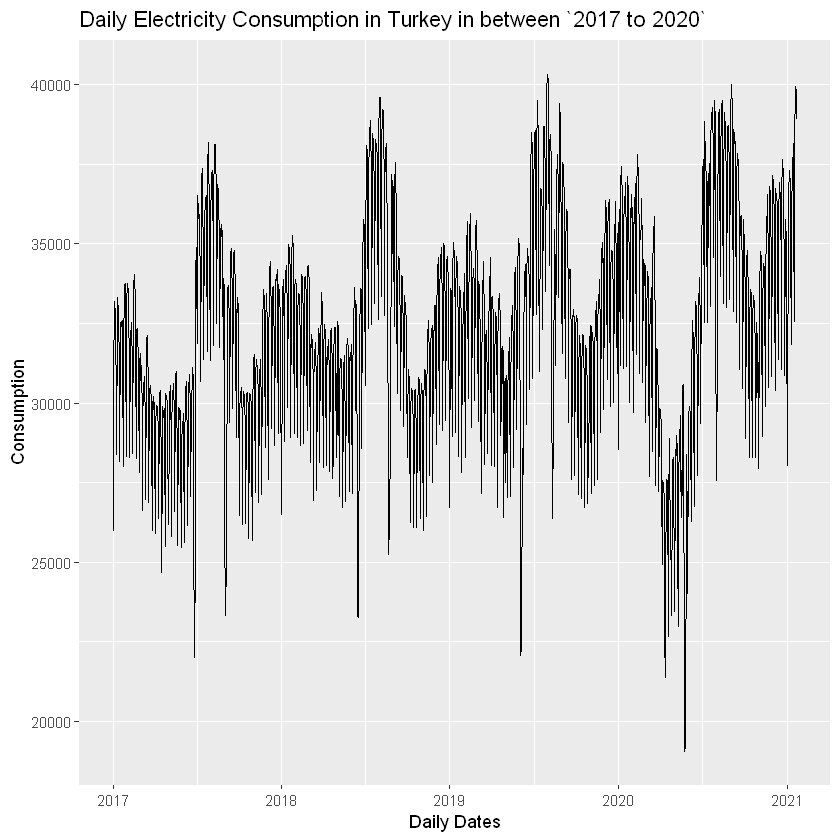

```python
ggplot(dt[1:(.N-10)], aes(x=date, y=consumption))+geom_line()+labs(title="Daily Electricity Consumption in Turkey in between `2017 to 2020`")+
                                                                   ylab("Consumption")+xlab("Daily Dates")
```

Lastly, auto.arima() function is used to determine the model which will be used in the daily mean prediction. Slicing windows technique is the major approach for prediction because it simulates the real submission process. In the arima model, xreg is used to explain variations in the decomposed dataset. Factoral features were eliminated by preprocessing the dataset, so only other features were added to feature dataset. In addition, only temperature value applied PCA method is added to feature dataset to avoid to multicollinearity. The first prediction was made for in between "2021-01-09" and "2021-01-22". These days were selected to make target dates as similar as the future prediction time period.

Decompostion is used in the Time-Series model. Before deciding the input is proper for time-series model or not, different controls were made. Some of these controls are as follows:

#### Outlier Check

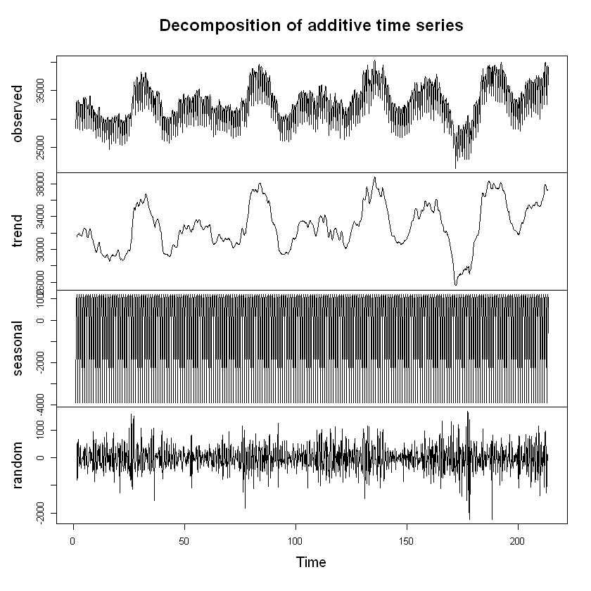

```python
check_random=decompose(ts(pred_dt[date<"2021-01-31",]$consumption,freq=7),type='add')
plot(check_random)
```

Much as the trend of the decomposed consumption value with freq=7. Randoms are located at zero mean and variance can be accepted as stationary in terms of variation. There is a variation in the beginning period of the pandemic but feature matrix will include covid-severity information, which can enable model to explain this variation by this informationd dataset.

#### Unit Root Test

```python
unt_test_final=ur.kpss(last_decomp$random)
summary(unt_test_final)
```

```
#######################
# KPSS Unit Root Test #
#######################

Test is of type: mu with 7 lags.

Value of test-statistic is: 0.0069

Critical value for a significance level of:
                10pct  5pct 2.5pct  1pct
critical values 0.347 0.463  0.574 0.739
```

#### Ljung-Box Test

```python
Box.test(last_decomp$random, lag=10, type="Ljung-Box")
```

```
	Box-Ljung test

data:  last_decomp$random
X-squared = 743.65, df = 10, p-value < 2.2e-16
```

This suggests that seasonality terms must be added to model to obtain unrelated random values from the decomposition. In the arima model, seasonality feature is selected as true for this test.

Moreover, which feature must be added to xreg function is determined by using linear regression. In the linear regression, step function is used to determine those feature. In addition, selected features with step function are plotted with linear regression's residuals. After this process, some features are manipulated. For example, abs_reduced_tmp and abs_reduced_tmp_max are added to feature dataset. How to determined these features can be found as follows:

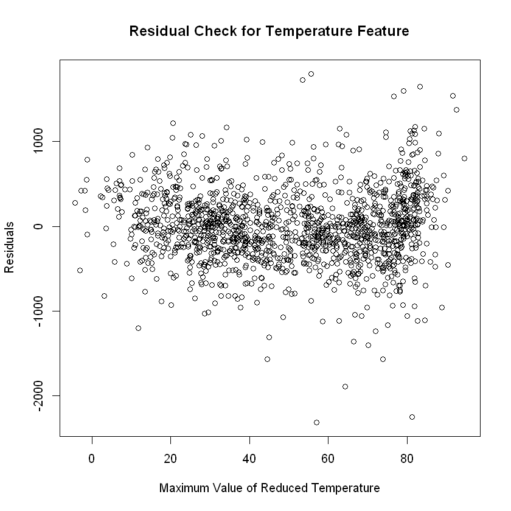

```python
plot(random_dataset$reduced_tmp_max, lm2$residuals, main="Residual Check for Temperature Feature",
                                                    ylab="Residuals", xlab="Maximum Value of Reduced Temperature")
```

This plot is one of the example for how to manipulated feature dataset. There is a non-linear relationship in between the residuals and temperature values. In order to make it linear, abs function is used. abs_reduced_tmp_max:=abs(reduced_tmp_max-55) was used to obtain this value which has linear relationship with the residuals.

Model is selected with using the auto.arima function. Result for auto.arima() function is as follows:

```python
fitted=auto.arima(last_decomp$random,trace=T)
```

```
 Fitting models using approximations to speed things up...

 ARIMA(2,0,2)(1,0,1)[7] with non-zero mean : Inf
 ARIMA(0,0,0)           with non-zero mean : 21964.84
 ARIMA(1,0,0)(1,0,0)[7] with non-zero mean : 21779.02
 ARIMA(0,0,1)(0,0,1)[7] with non-zero mean : 21726.25
 ARIMA(0,0,0)           with zero mean     : 21962.83
 ARIMA(0,0,1)           with non-zero mean : 21771.95
 ARIMA(0,0,1)(1,0,1)[7] with non-zero mean : 21696.12
 ARIMA(0,0,1)(1,0,0)[7] with non-zero mean : 21711.95
 ARIMA(0,0,1)(2,0,1)[7] with non-zero mean : 21698.16
 ARIMA(0,0,1)(1,0,2)[7] with non-zero mean : 21697.97
 ARIMA(0,0,1)(0,0,2)[7] with non-zero mean : 21711.65
 ARIMA(0,0,1)(2,0,0)[7] with non-zero mean : 21704.45
 ARIMA(0,0,1)(2,0,2)[7] with non-zero mean : 21700.18
 ARIMA(0,0,0)(1,0,1)[7] with non-zero mean : 21868.39
 ARIMA(1,0,1)(1,0,1)[7] with non-zero mean : 21697.12
 ARIMA(0,0,2)(1,0,1)[7] with non-zero mean : 21615.2
 ARIMA(0,0,2)(0,0,1)[7] with non-zero mean : 21610.69
 ARIMA(0,0,2)           with non-zero mean : 21625.16
 ARIMA(0,0,2)(0,0,2)[7] with non-zero mean : Inf
 ARIMA(0,0,2)(1,0,0)[7] with non-zero mean : 21614.7
 ARIMA(0,0,2)(1,0,2)[7] with non-zero mean : 21608.44
 ARIMA(0,0,2)(2,0,2)[7] with non-zero mean : Inf
 ARIMA(0,0,2)(2,0,1)[7] with non-zero mean : Inf
 ARIMA(1,0,2)(1,0,2)[7] with non-zero mean : Inf
 ARIMA(0,0,3)(1,0,2)[7] with non-zero mean : 21244.22
 ARIMA(0,0,3)(0,0,2)[7] with non-zero mean : Inf
 ARIMA(0,0,3)(1,0,1)[7] with non-zero mean : 21255.27
 ARIMA(0,0,3)(2,0,2)[7] with non-zero mean : Inf
 ARIMA(0,0,3)(0,0,1)[7] with non-zero mean : Inf
 ARIMA(0,0,3)(2,0,1)[7] with non-zero mean : Inf
 ARIMA(1,0,3)(1,0,2)[7] with non-zero mean : Inf
 ARIMA(0,0,4)(1,0,2)[7] with non-zero mean : 21217.4
 ARIMA(0,0,4)(0,0,2)[7] with non-zero mean : Inf
 ARIMA(0,0,4)(1,0,1)[7] with non-zero mean : 21229.92
 ARIMA(0,0,4)(2,0,2)[7] with non-zero mean : Inf
 ARIMA(0,0,4)(0,0,1)[7] with non-zero mean : Inf
 ARIMA(0,0,4)(2,0,1)[7] with non-zero mean : Inf
 ARIMA(1,0,4)(1,0,2)[7] with non-zero mean : Inf
```

[output cut: 18 more lines]

```

 ARIMA(0,0,5)(1,0,2)[7] with zero mean     : Inf
 ARIMA(0,0,5)(1,0,2)[7] with non-zero mean : Inf
 ARIMA(0,0,4)(1,0,2)[7] with zero mean     : Inf
 ARIMA(0,0,4)(1,0,2)[7] with non-zero mean : Inf
 ARIMA(0,0,5)(1,0,1)[7] with zero mean     : Inf
 ARIMA(0,0,5)(1,0,1)[7] with non-zero mean : Inf
 ARIMA(0,0,4)(1,0,1)[7] with non-zero mean : Inf
 ARIMA(0,0,3)(1,0,2)[7] with non-zero mean : Inf
 ARIMA(0,0,3)(1,0,1)[7] with non-zero mean : Inf
 ARIMA(0,0,2)(1,0,2)[7] with non-zero mean : Inf
 ARIMA(0,0,2)(0,0,1)[7] with non-zero mean : Inf
 ARIMA(0,0,2)(1,0,0)[7] with non-zero mean : 21608.96

 Best model: ARIMA(0,0,2)(1,0,0)[7] with non-zero mean
```

#### Obtained results with auto-arima function

```python
fitted
```

```
Series: last_decomp$random
ARIMA(0,0,2)(1,0,0)[7] with non-zero mean

Coefficients:
          ma1      ma2    sar1     mean
      -0.2687  -0.6777  0.1249  -0.0348
s.e.   0.0181   0.0166  0.0284   0.6382

sigma^2 estimated as 152788:  log likelihood=-10799.46
AIC=21608.92   AICc=21608.96   BIC=21635.35
```

#### Residual Check for obtained model

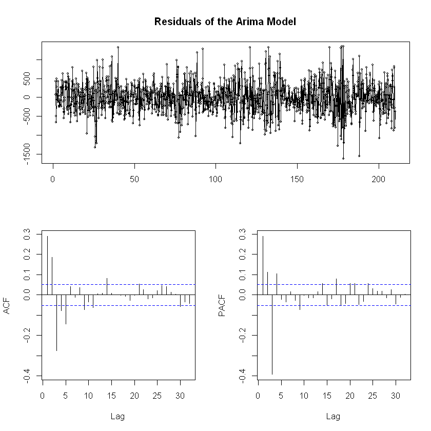

```python
tsdisplay(fitted$residuals, main="Residuals of the Arima Model")
```

Residuals are checked by tsdisplay() function and ACF & PACF can be used to modify the auto.arima() function. By looking the ACF plot, there is a smooth change compared to PACF plot. In this manner, AR terms must be added to time-series model, and lag value must be determined by looking the PACF plot. 3 is one of the reasonable value for AR terms, which must makes model less auto-correlated.

#### New time-series model after the modification in the parameter values

```python
fit_mod=arima(last_decomp$random, order=c(3,0,2), seasonal = list(order = c(0, 0, 1), period = 7))
fit_mod
```

```
Call:
arima(x = last_decomp$random, order = c(3, 0, 2), seasonal = list(order = c(0,
    0, 1), period = 7))

Coefficients:
         ar1     ar2      ar3      ma1      ma2    sma1  intercept
      0.1212  0.3914  -0.4867  -0.0875  -0.8533  0.1125    -0.0177
s.e.  0.0653  0.0653   0.0358   0.0649   0.0649  0.0278     0.6172

sigma^2 estimated as 116806:  log likelihood = -10605.32,  aic = 21226.63
```

AIC is one of the good indicator for performance of the model if all models use the same dataset to build model. Namely, it can be said that there is an improvement in the time-series model. In addition, residual check must be controlled to determined auto-correlation problem is solved or not.

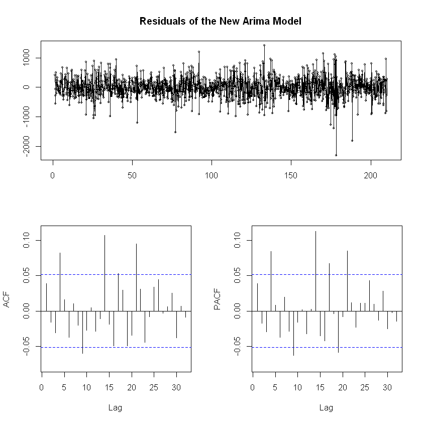

```python
tsdisplay(fit_mod$residuals, main="Residuals of the New Arima Model")
```

Much as there are still some problem in terms of auto-correlation, better model is achieved by adding AR terms to model. In addition, these parameters can be explained by xreg regressor, which makes the model as a candidate option for time-series models. To sum up, ARIMA(3,0,2)(0, 0, 1)[7] will be used with xreg regressor to predict future consumption values. The final decision related to which model will be used will be determined after the result section.

### Liner Regression with Lasso Penalty

Linear Regression with Lasso Penalty enable us to use hourly prediction models because models can determine which features are critical for designated hour by penalty. Indeed, there are 2 common penalty types, Lasso and Ridge. Much as these penalty types have similarity, Lasso penalty tends to select less feature for final model. By knowing number of independent variable is large enough, lasso is prefered to ridge regression. In order to use Lasso regression, factorial features converted to dummy variables. Moreover, hourly models have a difference from daily model, which is having 24 different value for lag2 and lag7. Namely, 48 different values are added to feature dataset with lag2 and lag7. At the end, 81 different features exist for the linear regression model with lasso, which also makes the lasso penalty more reasonable to ridge penalty. PCA didn't be used in the Lasso regression because temperature values can be eliminated by the penalty term in the regressor.

Slicing window method for prediction is also the major method for predicting future electricity consumption because it simulates the real submission system and to obtain lag2 values in the dataset. For this model, percentage calculation is unnecessary because all the hours in consumption are predicted with 24 different model, so it is the one of the main advantages of this model.

In addition all the hours' models parameters were tuned by using glmnet library. nfolds were assigned as 10 in the cross-validation process in the lambda selection. In addition different types of measure were also tried to find best option for lambda tuning. In the models, mae is selected as type.measure for tuning. In addition, details of one of the hours' model can be found as follows:

### Lambda Plot for 12'th Hour

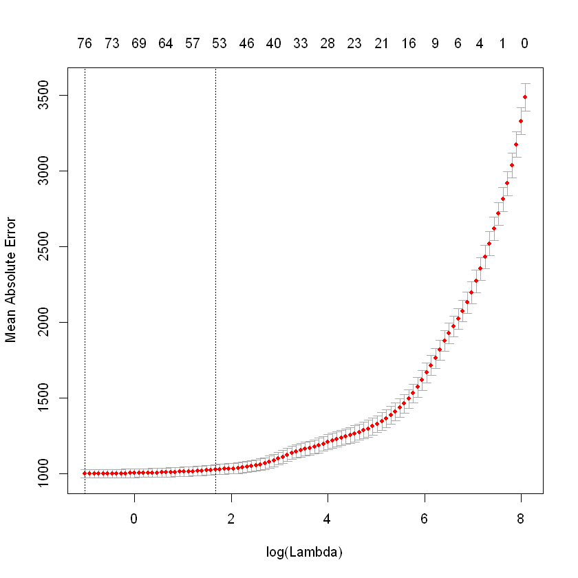

```python
plot(cvfit12)
```

### Coefficient for 12'th Hour Model

```python
coef(cvfit12)
```

```
81 x 1 sparse Matrix of class "dgCMatrix"
                                              1
(Intercept)                        3.053876e+03
Lag_day2_hour_0                    3.757362e-02
Lag_day2_hour_1                    .
Lag_day2_hour_2                   -2.190965e-01
Lag_day2_hour_3                   -2.366374e-01
Lag_day2_hour_4                    .
Lag_day2_hour_5                    .
Lag_day2_hour_6                   -2.850775e-02
Lag_day2_hour_7                    6.725729e-01
Lag_day2_hour_8                   -4.677316e-01
Lag_day2_hour_9                   -3.648375e-01
Lag_day2_hour_10                   .
Lag_day2_hour_11                  -5.223172e-02
Lag_day2_hour_12                   3.464457e-02
Lag_day2_hour_13                   6.057329e-01
Lag_day2_hour_14                   .
Lag_day2_hour_15                   .
Lag_day2_hour_16                   .
Lag_day2_hour_17                  -7.607681e-05
Lag_day2_hour_18                  -1.316160e-03
Lag_day2_hour_19                  -4.851522e-02
Lag_day2_hour_20                   4.271815e-02
Lag_day2_hour_21                   3.497766e-01
Lag_day2_hour_22                   .
Lag_day2_hour_23                   3.529288e-01
Lag_day7_hour_0                    1.830261e-01
Lag_day7_hour_1                    1.851174e-01
Lag_day7_hour_2                    .
Lag_day7_hour_3                    .
Lag_day7_hour_4                    .
Lag_day7_hour_5                   -1.694712e-01
Lag_day7_hour_6                   -2.262437e-01
Lag_day7_hour_7                    8.447410e-02
Lag_day7_hour_8                    .
Lag_day7_hour_9                   -1.015481e-02
Lag_day7_hour_10                   .
Lag_day7_hour_11                   .
Lag_day7_hour_12                   2.921229e-01
```

[output cut: 28 more lines]

```
ramadan_eve                       -9.071317e+03
monday_or_friday_between_holidays -2.129826e+03
extra_holidays                     7.893306e+02
extra_holidays_2                  -2.262934e+03
partial_lockdown                   2.882677e+03
full_lockdown                     -5.198126e+02
T_1                                .
T_2                               -1.145030e+01
T_3                                2.080783e+00
T_4                                4.159637e+01
T_5                               -9.253849e+01
T_6                                4.897701e+01
T_7                                .
lockdown_partially                -1.032501e+02
sun_hourly                         .
```

### Mininum value for Lambda of 12'th Hour Model

```python
cvfit12$lambda.min
```

0.35912456947196

### 1se value for Lambda of 12'th Hour Model

```python
cvfit12$lambda.1s
```

5.33288586521671

### Summary of the 12'th Hour Model

```python
summary(cvfit12)
```

```
           Length Class  Mode
lambda     99     -none- numeric
cvm        99     -none- numeric
cvsd       99     -none- numeric
cvup       99     -none- numeric
cvlo       99     -none- numeric
nzero      99     -none- numeric
name        1     -none- character
glmnet.fit 12     elnet  list
lambda.min  1     -none- numeric
lambda.1se  1     -none- numeric
```

By considering these plots and information, all the models were tuned to obtain best results for future predictions.

### General Comparision of Models

In the arima model, feature dataset is manipulated with step function and controlling the residuals in the linear regression model. In addition, factorial features and possible multicollineariy problem is blocked with removing these features effect in the past data and using PCA methodology. The biggest downside of the time-series model is to doesn't have specialized dataset for all hours and after-processing after predicting the daily mean consumption. In addition, after-processing can have some problems because Covid-19 has different effect in the consumption pattern in the electricity. For example, there is partial lockdowns for determined hours by government. In addition, it hard to remove its' effect because this situation exists for limited time period(2 month). Also, removing effect of this partion lackdown doesn't look like reasonable because it will contiue in the period of the submission prediction. To sum up, time-series model is more proper for predicting the electricity consumption, but it is hard to convert this value to hourly version because of the new revealed partial lockdown system.

In the linear regression model with lasso penalty, which feature is critical for each hours consumption can be determined by the models. In addition, hourly prediction enable us to integrate partial lockdown information for each hour and whether sun is rised or not for determined hour can be added to model. For each hour, these feature can be eliminated by the models. By considering the size of the feature dataset, lasso penalty is choosen for the linear regression and specialized feature dataset can be a reason for chosing this model to time-series model.

Final model will be determined by the obtained results, but general comparision gave some intuition related to models.

# 4. Results

To make prediction period more similar with prediction period is selected as "2021-01-09" to "2021-01-22". In addition to this period, different time zones are selected to test models. These time zones are selected by considering the month information, similarity between the real prediction period, different lengths(1, 2, 3 months). However, the final decision is taken by considering the mentioned time period. One of the reason for selecting this time period is effect of the pandemic in electricity consumption. Previous years' january and february months doesn't includes the effect of the pandemic and partial lockdowns are applied after the December 2020. So, this period is the most convinient period to test models' predictions with real consumption values.

## Naive Model

2 different result obtained by naive model. One of the daily prediction and the other is hourly prediction. Both Lag 48 and Lag 168 are used to predict future consumption. Obtained results as follows:

### Hourly Prediction

```python
perf_dt("Lag 48 for hourly prediction", test$Consumption, test$Lag_48)
perf_dt("Lag 168 for hourly prediction", test$Consumption, test$Lag_168)
```

| name | n | mean | sd | FBias | MAPE | RMSE | MAD | WMAPE |
| --- | --- | --- | --- | --- | --- | --- | --- | --- |
| Lag 48 for hourly prediction | 336 | 37045.79 | 5444.545 | 0.008716181 | 0.1713854 | 403.6515 | 6137.928 | 0.1656849 |

| name | n | mean | sd | FBias | MAPE | RMSE | MAD | WMAPE |
| --- | --- | --- | --- | --- | --- | --- | --- | --- |
| Lag 168 for hourly prediction | 336 | 37045.79 | 5444.545 | 0.04073002 | 0.1580881 | 394.6597 | 5804.765 | 0.1566916 |

Lag 168 gave better result compared to lag 48, which is also expected by looking the ACF plot of the consumption values.

### Daily Prediction

```python
perf_dt("Lag 2 for daily prediction", test$Consumption, test$Lag_2)
perf_dt("Lag 7 for daily prediction", test$Consumption, test$Lag_7)
```

| name | n | mean | sd | FBias | MAPE | RMSE | MAD | WMAPE |
| --- | --- | --- | --- | --- | --- | --- | --- | --- |
| Lag 2 for daily prediction | 14 | 889099 | 61616.14 | 0.008716181 | 0.07486176 | 21854.45 | 64694.99 | 0.07276466 |

| name | n | mean | sd | FBias | MAPE | RMSE | MAD | WMAPE |
| --- | --- | --- | --- | --- | --- | --- | --- | --- |
| Lag 7 for daily prediction | 14 | 889099 | 61616.14 | 0.04073002 | 0.04087209 | 12136.03 | 36213.03 | 0.04073002 |

Similar to previous results Lag 7 gave better result compared to lag 2 in daily consumption prediction. The main aim of these two results are to compare obtained results with these 2 model. In addition to time-series model and linear regression with lasso penalty, different models are created. Which models are created can be found at approach section. In addition, these models' code are also added to code section to find which results are obtained in these models.

## Time Series Model

The obtained results with ARIMA model is as follows:

### Predictions and Actual Values for Time-series model with regressor

```python
res_dt
```

| date | consumption | forecasted | diff |
| --- | --- | --- | --- |
| 2021-01-09 | 34781.56 | 34361.04 | 420.5193 |
| 2021-01-10 | 31841.90 | 30931.57 | 910.3289 |
| 2021-01-11 | 36431.46 | 35647.06 | 784.4072 |
| 2021-01-12 | 36897.99 | 36550.56 | 347.4377 |
| 2021-01-13 | 37409.87 | 36869.89 | 539.9804 |
| 2021-01-14 | 38056.05 | 37135.84 | 920.2092 |
| 2021-01-15 | 38170.38 | 36823.17 | 1347.2067 |
| 2021-01-16 | 35667.35 | 34700.91 | 966.4388 |
| 2021-01-17 | 32557.96 | 31426.35 | 1131.6122 |
| 2021-01-18 | 38447.89 | 36101.42 | 2346.4704 |
| 2021-01-19 | 39723.73 | 36877.32 | 2846.4176 |
| 2021-01-20 | 39960.92 | 36981.73 | 2979.1902 |
| 2021-01-21 | 39791.07 | 36996.33 | 2794.7367 |
| 2021-01-22 | 38902.97 | 36747.99 | 2154.9850 |

All the forecasted values are below the actual consumption values, which is a problem for model. This situation can be also observed in the perfomance measure of model in the Forecast Bias section. In addition, it can be said that these results' deviation be increased in the convertion in the daily prediction to hourly prediction.

### Performance Measure for ARIMA model with regressor

```python
perf_dt("Predictions in Arima with Slicing Window and regressor", res_dt$consumption, res_dt$forecasted)
```

| name | n | mean | sd | FBias | MAPE | RMSE | MAD | WMAPE |
| --- | --- | --- | --- | --- | --- | --- | --- | --- |
| Predictions in Arima with Slicing Window and regressor | 14 | 37045.79 | 2567.339 | 0.03950697 | 0.03858966 | 462.069 | 1463.567 | 0.03950697 |

There is a slightly increase in the performance of the prediction compared to daily prediction in naive model. However, this result can be deviated with regressor, because model can be overfitted to train dataset. In addition, some features in the feature dataset appears only limited time periods. For example, information related to covid has different than zero for at most 1 year. In addition, partial lockdown infomation exists for 2 months, which can also disturb the prediction. Over-fitting because of the regressor can be checked with comparing the results of the time-series model without regressor.

### Predictions and Actual Values for Time-series model without regressor

```python
res_dt
```

| date | consumption | forecasted | diff |
| --- | --- | --- | --- |
| 2021-01-09 | 34781.56 | 34565.77 | 215.794311 |
| 2021-01-10 | 31841.90 | 31326.56 | 515.343286 |
| 2021-01-11 | 36431.46 | 35872.96 | 558.507734 |
| 2021-01-12 | 36897.99 | 36903.63 | -5.636474 |
| 2021-01-13 | 37409.87 | 37191.53 | 218.336301 |
| 2021-01-14 | 38056.05 | 37200.91 | 855.138685 |
| 2021-01-15 | 38170.38 | 36959.10 | 1211.279731 |
| 2021-01-16 | 35667.35 | 35672.18 | -4.838928 |
| 2021-01-17 | 32557.96 | 32497.06 | 60.896760 |
| 2021-01-18 | 38447.89 | 36560.38 | 1887.508197 |
| 2021-01-19 | 39723.73 | 37557.26 | 2166.469203 |
| 2021-01-20 | 39960.92 | 38462.34 | 1498.580161 |
| 2021-01-21 | 39791.07 | 39059.92 | 731.149519 |
| 2021-01-22 | 38902.97 | 38639.61 | 263.363163 |

Still, underpredicting exist for this model, but there is an improvement. Value of Forecasted Bias for this model also confirm this situation.

### Performance Measure for ARIMA model without regressor

```python
perf_dt("Predictions in Arima with Slicing Window and without regressor", res_dt$consumption, res_dt$forecasted)
```

| name | n | mean | sd | FBias | MAPE | RMSE | MAD | WMAPE |
| --- | --- | --- | --- | --- | --- | --- | --- | --- |
| Predictions in Arima with Slicing Window and without regressor | 14 | 37045.79 | 2567.339 | 0.01961258 | 0.01901392 | 267.0696 | 728.0602 | 0.01965298 |

After removing the regressor, model became better. Therefore, it can be said that regressor can cause an overfitting problem. In addition, some features have signifanct role in the hourly electricity consumption but the same feature may doesn't have any impact in other hours. However, it is hard to predict this situation by daily mean. This fact makes lasso regression more useful for predictions. In addition, all the time series models requires additional computation for converting daily consumption to hourly. This situation is also a problematic for time-series models because partial lockdowns exist only for limited time periods. So, use of previous percentage usage for hours from past years january and february months doesn't seems logical. These 2 situation makes more reasonable to use hourly models with 24 model and auto selection for features with lasso regression. However, last decision must be taken after the results of the lasso model.

## Linear Regression with Lasso Model

The main advantage of the linear regression with the lasso model is that an extra process doesn't be required in this model because all the estimation was made at the hourly level. In addition, all the features' significance will be evaluated for each hour seperately. This situation is also particular for this model. Moreover, lambda value can be selected for considering the current rank in the leaderboard. If best score is required for getting high daily rank score, lambda.min can be chosen to achive this goal.

### Predictions and Actual Values for Linear Regression with Lasso Regression

```python
res_dt
```

| date | hour | actual | forecasted |
| --- | --- | --- | --- |
| 2021-01-09 | 0 | 34179.62 | 33178.10 |
| 2021-01-09 | 1 | 32540.12 | 31464.26 |
| 2021-01-09 | 2 | 31207.36 | 30205.43 |
| 2021-01-09 | 3 | 30300.31 | 29402.32 |
| 2021-01-09 | 4 | 29733.83 | 29042.88 |
| 2021-01-09 | 5 | 29862.21 | 28971.42 |
| 2021-01-09 | 6 | 30043.88 | 29505.93 |
| 2021-01-09 | 7 | 30751.12 | 30114.48 |
| 2021-01-09 | 8 | 32581.69 | 32195.30 |
| 2021-01-09 | 9 | 34678.94 | 33998.37 |
| 2021-01-09 | 10 | 36166.38 | 35158.88 |
| 2021-01-09 | 11 | 37487.93 | 36024.52 |
| 2021-01-09 | 12 | 37211.80 | 35322.58 |
| 2021-01-09 | 13 | 37810.82 | 35825.85 |
| 2021-01-09 | 14 | 38101.10 | 36223.08 |
| 2021-01-09 | 15 | 37558.51 | 36125.82 |
| 2021-01-09 | 16 | 37309.02 | 36425.29 |
| 2021-01-09 | 17 | 37765.19 | 37215.25 |
| 2021-01-09 | 18 | 38809.94 | 38386.04 |
| 2021-01-09 | 19 | 37942.62 | 37756.24 |
| 2021-01-09 | 20 | 36954.46 | 36512.26 |
| 2021-01-09 | 21 | 36123.84 | 35453.07 |
| 2021-01-09 | 22 | 35388.72 | 34896.07 |
| 2021-01-09 | 23 | 34248.06 | 33531.82 |
| 2021-01-10 | 0 | 32362.57 | 31953.03 |
| 2021-01-10 | 1 | 30788.59 | 30220.48 |
| 2021-01-10 | 2 | 29431.82 | 28942.18 |
| 2021-01-10 | 3 | 28455.28 | 28129.39 |
| 2021-01-10 | 4 | 28145.71 | 27676.73 |
| 2021-01-10 | 5 | 28011.47 | 27539.42 |
| ... | ... | ... | ... |
| 2021-01-21 | 18 | 44034.50 | 42389.03 |
| 2021-01-21 | 19 | 42953.85 | 41551.39 |
| 2021-01-21 | 20 | 41215.75 | 40381.41 |
| 2021-01-21 | 21 | 40270.05 | 39425.60 |
| 2021-01-21 | 22 | 39507.50 | 39113.54 |
| 2021-01-21 | 23 | 37831.05 | 37730.59 |
| 2021-01-22 | 0 | 35612.55 | 35879.54 |
| 2021-01-22 | 1 | 33583.18 | 33816.82 |
| 2021-01-22 | 2 | 32344.92 | 32155.96 |
| 2021-01-22 | 3 | 31582.63 | 31157.91 |
| 2021-01-22 | 4 | 31246.16 | 30989.66 |
| 2021-01-22 | 5 | 31673.50 | 31156.82 |
| 2021-01-22 | 6 | 32489.70 | 32395.16 |
| 2021-01-22 | 7 | 34501.03 | 34169.91 |
| 2021-01-22 | 8 | 39239.50 | 38720.18 |
| 2021-01-22 | 9 | 42803.98 | 43090.40 |
| 2021-01-22 | 10 | 44943.01 | 45060.66 |
| 2021-01-22 | 11 | 45582.85 | 45937.39 |
| 2021-01-22 | 12 | 43969.54 | 45159.20 |
| 2021-01-22 | 13 | 42997.69 | 44233.91 |
| 2021-01-22 | 14 | 43583.40 | 45106.64 |
| 2021-01-22 | 15 | 43049.93 | 44006.92 |
| 2021-01-22 | 16 | 42708.96 | 43063.88 |
| 2021-01-22 | 17 | 42809.00 | 42804.40 |
| 2021-01-22 | 18 | 42609.98 | 42552.69 |
| 2021-01-22 | 19 | 41373.39 | 41518.26 |
| 2021-01-22 | 20 | 40013.85 | 40230.93 |
| 2021-01-22 | 21 | 39211.38 | 39176.89 |
| 2021-01-22 | 22 | 38496.36 | 38995.33 |
| 2021-01-22 | 23 | 37244.88 | 37788.42 |

Still, there is an under-predicting problem in the model but this problem was more dramatic in the previous models. Lambda.min was used to predict displayed values. Much as lambda.min choose can cause over-fitting in the model, it is hard to say that there is an over-fitting problem. In addition, partial lockdown exists for this time period, and model has a good estimation in those lockdown hours, which is a critical information related to results of the model. Lastly, general performance of the model must be checked to determine final decision related to which model must be used for prediction.

### Performance Measure for Linear Regression with Lasso Penalty

```python
perf_dt("Linear Regression with Lasso Penalty", res_dt$actual, res_dt$forecasted)
```

| name | n | mean | sd | FBias | MAPE | RMSE | MAD | WMAPE |
| --- | --- | --- | --- | --- | --- | --- | --- | --- |
| Linear Regression with Lasso Penalty | 336 | 37045.79 | 5444.545 | 0.01388135 | 0.01928711 | 52.83225 | 744.4805 | 0.02009622 |

# 5. Conclusion and Future works

## 5.1. Conclusion

In this project, we investigated Turkey's electricity consumption demand to obtain patterns and reach more accurate forecasts for a better insigth that will lead more optimal production decisions. We analysed a time-series data via both visually and analytically. We experimented on the data with naive and commonly used models and dealt with challenges that became apparent after these experiments. After reaching sufficient conditions of industry and our standarts (e.g. stationarity, outlier correction), we fitted chosen models and using classic time series cross-validation train-test split to avoid overfitting, we decided on the best model controlling performance metrics of these models. Then, using all available data up to date, we made forecasts with our model for each day of the competition period. These were further corrected with manuel inspection and calibration using prior dateset values. Machine Learning methods and manuel corrections led us to WMAPE score of approximately 0.025 for the time period of "2021-01-30" to "2021-02-13" that was the target period of our project.

## 5.2. Future Works

Time-series quality of our data is hard to deal with due to time mismatch and requirement of working with forecasts of external regressors are necessary, resulting in unavoidable forecast errors. These forecast values can be improved in time by the sources who makes these that are used in the model. Improvements to our results, that can be performed by future workers, can be investigated under two main branches: data processing (e.g. pre-processing) and model selection. Firstly, feature set of external regressors can be expanded to reach better precision, however one should be careful with overfitting & multicollinearity & feature search costs. Data in our hands was hourly dataset, and some of our approaches were based on hourly predictions directly. However, daily analysis and predictions were also found to be a viable approach in the process and these daily predictions could be fed into a function for hourly estimations. However, insufficient amount of data led higher than wanted errors here and with the availability of data, this approach should be visited again. Also, outlier manipulations can be improved with approaches within the machine learning and energy consumption literatures. The most important challange for this project was indoubtedly COVID-19 pandemic since the effects imprecise and variant leading to a blurry overall picture. We used Google Trend data for COVID-19 topic to handle this issue but further investigations on improvement of the pandemic interval may reach better results in time. Model selection in this project relied on Statistical Analysis Models due to aforementioned reasons. However, Computational Intelligence Models, Grey Prediction Models and amalgamation of these that are commonly used in the literature may lead better results. However, computation costs and additional feature search for these models have other downsides that should be considered by interested parties.

# 6. Code

#### General Github Repository Link

https://github.com/mbahadir/360project_files

#### Initial Models

Notebook: https://github.com/mbahadir/360project_files/blob/main/Initial%20Models.ipynb

R Script: https://github.com/mbahadir/360project_files/blob/main/Initial%20Models.r

#### Consumption Visualization

Notebook: https://github.com/mbahadir/360project_files/blob/main/Consumption%20Visualization.ipynb

R Script: https://github.com/mbahadir/360project_files/blob/main/Consumption%20Visualization.r

#### Feature Dataset Update

Notebook: https://github.com/mbahadir/360project_files/blob/main/Update%20datas.ipynb

Python Script: https://github.com/mbahadir/360project_files/blob/main/Update%20datas.py

#### Hours’ Percentage Consumption Estimation with ARIMA

Notebook: https://github.com/mbahadir/360project_files/blob/main/Hour%20Estimation%20with%20arima.ipynb

R Script: https://github.com/mbahadir/360project_files/blob/main/Hour%20Estimation%20with%20arima.r

#### PCA implementation on Temperature Values

Notebook: https://github.com/mbahadir/360project_files/blob/main/PCA%20Calculation.ipynb

R Script: https://github.com/mbahadir/360project_files/blob/main/PCA%20Calculation.r

#### Residual Analysis

Notebook: https://github.com/mbahadir/360project_files/blob/main/Residual%20Check.ipynb

R Script: https://github.com/mbahadir/360project_files/blob/main/Residual%20Check.r

#### Base Models

Notebook: https://github.com/mbahadir/360project_files/blob/main/Base%20Models%20.ipynb

R Script: https://github.com/mbahadir/360project_files/blob/main/Base%20Models%20.r

#### ARIMA Model

Notebook: https://github.com/mbahadir/360project_files/blob/main/Arima%20Model.ipynb

R Script: https://github.com/mbahadir/360project_files/blob/main/Arima%20Model.r

#### Linear Regression with Lasso Penalty

Notebook: https://github.com/mbahadir/360project_files/blob/main/Lasso%20Model.ipynb

R Script: https://github.com/mbahadir/360project_files/blob/main/Lasso%20Model.r

# 7. References

```
Li, Kai & Zhang, Tao. (2018). Forecasting Electricity Consumption Using an Improved Grey Prediction Model. Information. 9. 204. 10.3390/info9080204.

Ediger, Volkan & Akar, Sertac. (2007). ARIMA forecasting of primary energy demand by fuel in Turkey. Energy Policy. 35. 1701-1708. 10.1016/j.enpol.2006.05.009.

Kaytez, Fazil & Taplamacioglu, M. & Çam, Ertuğrul & Hardalaç, Firat. (2015). Forecasting electricity consumption: A comparison of regression analysis, neural networks and least squares support vector machines. International Journal of Electrical Power & Energy Systems. 67. 10.1016/j.ijepes.2014.12.036.

Tureczek, Alexander. (2017). Structured Literature Review of Electricity Consumption Classification Using Smart Meter Data. Energies. 10. 584. 10.3390/en10050584.

Gamze Oğcu, Omer F. Demirel, Selim Zaim, Forecasting Electricity Consumption with Neural Networks and Support Vector Regression, Procedia - Social and Behavioral Sciences, Volume 58, 2012, Pages 1576-1585, ISSN 1877-0428, https://doi.org/10.1016/j.sbspro.2012.09.1144.

P. Ozoh, S. Abd-Rahman and J. Labadin, "Predicting electricity consumption: A comparative analysis of the accuracy of various computational techniques," 2015 9th International Conference on IT in Asia (CITA), Sarawak, Malaysia, 2015, pp. 1-7, doi: 10.1109/CITA.2015.7349819.

M. Bouzerdoum, A. Mellit, A. Massi Pavan, A hybrid model (SARIMA–SVM) for short-term power forecasting of a small-scale grid-connected photovoltaic plant, Solar Energy, Volume 98, Part C, 2013, Pages 226-235, ISSN 0038-092X, https://doi.org/10.1016/j.solener.2013.10.002.

Şahin, U . "FORECASTING OF TURKEY’S ELECTRICITY GENERATION AND CONSUMPTION WITH GREY PREDICTION METHOD" . Mugla Journal of Science and Technology 4 (2018): 205-209 <https://dergipark.org.tr/en/pub/muglajsci/issue/39930/450307>

Zaid Mohamed, Pat Bodger,Forecasting electricity consumption in New Zealand using economic and demographic variables, Energy, Volume 30, Issue 10, 2005, Pages 1833-1843, ISSN 0360-5442, https://doi.org/10.1016/j.energy.2004.08.012.

Wang, Fei et al. “Residential Electricity Consumption Level Impact Factor Analysis Based on Wrapper Feature Selection and Multinomial Logistic Regression.” Energies 11.5 (2018): 1180, https://doi.org/10.3390/en11051180.

Weigang Zhao, Jianzhou Wang, Haiyan Lu, Combining forecasts of electricity consumption in China with time-varying weights updated by a high-order Markov chain model, Omega, Volume 45, 2014, Pages 80-91, ISSN 0305-0483, https://doi.org/10.1016/j.omega.2014.01.002.

Kaynar, Oguz & Ozekicioglu, Halil & Demirkoparan, Ferhan. (2017). Forecasting of Turkey's Electricity Consumption with Support Vector Regression and Chaotic Particle Swarm Algorithm. 15. 211-224.

Murat Kankal, Adem Akpınar, Murat İhsan Kömürcü, Talat Şükrü Özşahin, Modeling and forecasting of Turkey’s energy consumption using socio-economic and demographic variables, Applied Energy, Volume 88, Issue 5, 2011, Pages 1927-1939, ISSN 0306-2619, https://doi.org/10.1016/j.apenergy.2010.12.005.

Bilal ŞİŞMAN .A COMPARISON OF ARIMA AND GREY MODELS FOR ELECTRICITY CONSUMPTION DEMAND FORECASTING: THE CASE OF TURKEY. Kastamonu Üniversitesi İktisadi ve İdari Bilimler Fakültesi Dergisi (2016).
```